# All my homework

WenHan Qian

2024-12-08

# 第一次作业

## 第一次第一题

The Rayleigh density [156, Ch. 18] is
$$f(x) = \frac{x}{\sigma^2}
e^{-\frac{x^2}{2\sigma^2}}, \quad x \geq 0, \, \sigma >
0.$$

Develop an algorithm to generate random samples from a Rayleigh($\sigma$) distribution. Generate Rayleigh($\sigma$) samples for several choices of $\sigma>0$ and check that the mode of the generated samples is close to the theoretical mode $\sigma$ (check the histogram).

我们使用逆分布法，先生成均匀分布的随机数，再通过Rayleigh分布的累积分布函数的反函数进行转换。Rayleigh分布的累积分布函数为：
$$F(x) = 1 -
e^{-\frac{x^2}{2\sigma^2}}$$
我们用以下的公式生成Rayleigh随机样本
$$X = \sigma \sqrt{-2 \log(1 -
U)}$$

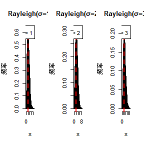

```r
# 逆分布法生成Rayleigh分布随机数的函数
rayleigh <- function(n, sigma) {
  # 生成n个[0, 1)区间的均匀随机数
  u <- runif(n)
  # 使用逆分布函数公式生成Rayleigh分布的随机数
  x <- sigma * sqrt(-2 * log(1 - u))
  return(x)
}

# 设置参数
sigma <- c(1, 2, 3)  # σ的不同取值
n <- 10000  # 每次生成的样本数量

# 生成Rayleigh分布样本并绘制直方图
par(mfrow = c(1, length(sigma)))  # 设置多图布局
for (sigma in sigma) {
  # 生成样本
  samples <- rayleigh(n, sigma)

  # 绘制直方图
  hist(samples, breaks = 50, col = "mediumseagreen", border = "black",
       main = paste("Rayleigh(σ=", sigma, ")", sep = ""),
       xlab = "x", ylab = "频率", freq = FALSE)
  abline(v = sigma, col = "red", lwd = 2, lty = 2)
  legend("topright", legend = paste("理论众数: σ =", sigma),
         col = "red", lwd = 2, lty = 2)
  }
```

对密度函数求导可得理论的众数应为$\sigma$，观察直方图可知这符合我们的估计

## 第一次第二题

问题描述如下：Generate a random sample of size 1000 from a normal location mixture. The components of the mixture have N(0, 1) and N(3, 1) distributions with mixing probabilities p1 and p2 = 1 − p1. Graph the histogram of the sample with density superimposed, for p1 = 0.75. Repeat with different values for p1 and observe whether the empirical distribution of the mixture appears to be bimodal. Make a conjecture about the values of p1 that produce bimodal mixtures

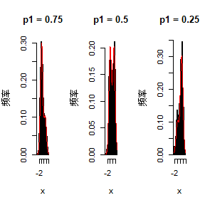

```r
set.seed(1)
# 混合正态分布样本生成函数
generate_mixture <- function(n, p1, mu1, mu2, sigma1, sigma2) {
  # 生成n个均匀分布的随机数用于决定成分
  u <- runif(n)

  # 使用混合概率p1选择不同成分的样本
  samples <- ifelse(u < p1, rnorm(n, mean = mu1, sd = sigma1), rnorm(n, mean = mu2, sd = sigma2))
  return(samples)
}

# 设置参数
n_samples <- 1000
mu1 <- 0
mu2 <- 3
sigma1 <- 1
sigma2 <- 1

# 生成混合分布样本
p1_values <- c(0.75, 0.5, 0.25)  # 不同的 p1 值

# 绘图
par(mfrow = c(1, length(p1_values)))  # 设置多图布局
for (p1 in p1_values) {
  # 生成混合分布样本
  samples <- generate_mixture(n_samples, p1, mu1, mu2, sigma1, sigma2)

  # 绘制样本的直方图
  hist(samples, breaks = 30, col = "mediumseagreen", border = "black", prob = TRUE,
       main = paste("p1 =", p1), xlab = "x", ylab = "频率")

  # 添加正态分布密度函数的叠加线
  curve(p1 * dnorm(x, mean = mu1, sd = sigma1) + (1 - p1) * dnorm(x, mean = mu2, sd = sigma2),
        col = "red", lwd = 1, add = TRUE)
}
```

可以从图中看出，当p1=0.5时双峰效应最明显，猜测p1越靠近0或者1，则双峰效应越不明显

## 第一次第三题

问题描述如下： A compound Poisson process is a stochastic process $\{X(t),t\geq0\}$ that can be represented as the random $X(t)=\sum_{i=1}^{N(t)}Y_i, t\geq0$, where $\{N(t),t\geq0\}$ is a Poisson process and $Y_1,Y_2,\ldots$ iid and independent of $\{N(t),t\geq0\}$. Write a program to simulate a compound Poisson(λ)–Gamma process (Y has a Gamma distribution). Estimate the mean and the variance of X(10) for several choices of the parameters and compare with the theoretical values.

我们首先选用的参数如下:$\lambda=1$,$\alpha=1$,$\beta=1$,模拟次数$num=10000$

```r
set.seed(1)
# 设置参数
lambda <- 1  # 泊松过程的参数
alpha <- 1   # Gamma分布的形状参数
beta <- 1    # Gamma分布的尺度参数
t <- 10       # 时间点 X(t)

# 模拟次数
num <- 10000

# 模拟复合泊松-伽马过程
X_t <- numeric(num)

for (i in 1:num) {
  N_t <- rpois(1, lambda * t)
  if (N_t > 0) {
    Y <- rgamma(N_t, shape = alpha, rate = beta)
    X_t[i] <- sum(Y)
  } else {
    X_t[i] <- 0
  }
}

# 估计 X(t) 的均值和方差
e_mean <- mean(X_t)
e_variance <- var(X_t)

# 理论均值和方差
E_Y1 <- alpha / beta
E_Y1_square <- (alpha * (alpha + 1)) / (beta ^ 2)
t_mean <- lambda * t * E_Y1
t_variance <- lambda * t * E_Y1_square

# 打印结果
cat("估计的均值:", e_mean, "\n")
```

```
## 估计的均值: 9.993612
```

```r
cat("理论的均值:", t_mean, "\n")
```

```
## 理论的均值: 10
```

```r
cat("估计的方差:", e_variance, "\n")
```

```
## 估计的方差: 19.79653
```

```r
cat("理论的方差:", t_variance, "\n")
```

```
## 理论的方差: 20
```

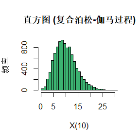

```r
# 绘制直方图
hist(X_t, breaks = 30, col = "mediumseagreen", border = "black", main = "直方图 (复合泊松-伽马过程)",
     xlab = "X(10)", ylab = "频率")
```

可以从上面的数据看出，在模拟次数为10000时，估计的方差和均值和理论的方差均值很接近。下面将改变模拟次数和分布参数给出另外两个例子

第二次选用的参数如下:$\lambda=1$,$\alpha=1$,$\beta=1$,模拟次数$num=1000$

```r
# 设置种子
set.seed(1)

# 设置参数
lambda <- 1  # 泊松过程的参数
alpha <- 1   # Gamma分布的形状参数
beta <- 1    # Gamma分布的尺度参数
t <- 10       # 时间点 X(t)

# 模拟次数
num <- 1000

# 模拟复合泊松-伽马过程
X_t <- numeric(num)

for (i in 1:num) {
  N_t <- rpois(1, lambda * t)
  if (N_t > 0) {
    Y <- rgamma(N_t, shape = alpha, rate = beta)
    X_t[i] <- sum(Y)
  } else {
    X_t[i] <- 0
  }
}

# 估计 X(t) 的均值和方差
e_mean <- mean(X_t)
e_variance <- var(X_t)

# 理论均值和方差
E_Y1 <- alpha / beta
E_Y1_square <- (alpha * (alpha + 1)) / (beta ^ 2)
t_mean <- lambda * t * E_Y1
t_variance <- lambda * t * E_Y1_square

# 打印结果
cat("估计的均值:", e_mean, "\n")
```

```
## 估计的均值: 10.04342
```

```r
cat("理论的均值:", t_mean, "\n")
```

```
## 理论的均值: 10
```

```r
cat("估计的方差:", e_variance, "\n")
```

```
## 估计的方差: 20.31624
```

```r
cat("理论的方差:", t_variance, "\n")
```

```
## 理论的方差: 20
```

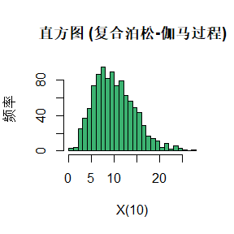

```r
# 绘制直方图
hist(X_t, breaks = 30, col = "mediumseagreen", border = "black", main = "直方图 (复合泊松-伽马过程)",
     xlab = "X(10)", ylab = "频率")
```

可以发现随着模拟次数的减少，此时估计值和理论值的差值变大了一个数量级

第三次选用的参数如下:$\lambda=2$,$\alpha=2$,$\beta=1$,模拟次数$num=10000$

```r
# 设置种子
set.seed(1)

# 设置参数
lambda <- 2  # 泊松过程的参数
alpha <- 2   # Gamma分布的形状参数
beta <- 1    # Gamma分布的尺度参数
t <- 10       # 时间点 X(t)

# 模拟次数
num <- 10000

# 模拟复合泊松-伽马过程
X_t <- numeric(num)

for (i in 1:num) {
  N_t <- rpois(1, lambda * t)
  if (N_t > 0) {
    Y <- rgamma(N_t, shape = alpha, rate = beta)
    X_t[i] <- sum(Y)
  } else {
    X_t[i] <- 0
  }
}

# 估计 X(t) 的均值和方差
e_mean <- mean(X_t)
e_variance <- var(X_t)

# 理论均值和方差
E_Y1 <- alpha / beta
E_Y1_square <- (alpha * (alpha + 1)) / (beta ^ 2)
t_mean <- lambda * t * E_Y1
t_variance <- lambda * t * E_Y1_square

# 打印结果
cat("估计的均值:", e_mean, "\n")
```

```
## 估计的均值: 39.97219
```

```r
cat("理论的均值:", t_mean, "\n")
```

```
## 理论的均值: 40
```

```r
cat("估计的方差:", e_variance, "\n")
```

```
## 估计的方差: 117.9874
```

```r
cat("理论的方差:", t_variance, "\n")
```

```
## 理论的方差: 120
```

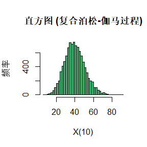

```r
# 绘制直方图
hist(X_t, breaks = 30, col = "mediumseagreen", border = "black", main = "直方图 (复合泊松-伽马过程)",
     xlab = "X(10)", ylab = "频率")
```

# 第二次作业

## 第二次第一题

问题描述如下：Write a function to compute a Monte Carlo estimate of the Beta(3, 3) cdf, and use the function to estimate F(x) for x = 0.1, 0.2,…, 0.9. Compare the estimates with the values returned by the pbeta function in R.

我们使用以下的函数来进行蒙特卡洛估计

```r
beta_cdf <- function(x, n = 100000) {
  # 生成n_sim个Beta(3, 3)分布的随机样本
  beta_samples <- rbeta(n, 3, 3)

  # 计算CDF的Monte Carlo估计
  cdf_estimate <- mean(beta_samples <= x)

  return(cdf_estimate)
}
```

取x=0.1,0.2,$\cdots$,0.9

```r
x_values <- seq(0.1, 0.9, by = 0.1)
mc_estimates <- sapply(x_values,beta_cdf)
```

使用pbeta函数计算Beta(3, 3)的CDF值，并比较Monte Carlo估计和pbeta函数的结果

```r
pbeta_values <- pbeta(x_values, 3, 3)
comparison <- data.frame(x = x_values,
                         Monte_Carlo_Estimate = mc_estimates,
                         pbeta_Value = pbeta_values)

print(comparison)
```

```
##     x Monte_Carlo_Estimate pbeta_Value
## 1 0.1              0.00834     0.00856
## 2 0.2              0.05810     0.05792
## 3 0.3              0.16403     0.16308
## 4 0.4              0.31906     0.31744
## 5 0.5              0.49890     0.50000
## 6 0.6              0.68410     0.68256
## 7 0.7              0.83833     0.83692
## 8 0.8              0.94218     0.94208
## 9 0.9              0.99171     0.99144
```

## 第二次第二题

问题描述如下：The Rayleigh density [156, (18.76)] is
$$f(x)=\frac{x}{\sigma^2}
e^{-x^2/(2\sigma^2)},\quad x\geq0, \sigma>0.$$
Implement a function to generate samples from a Rayleigh($\sigma$) distribution, using antithetic variables. What is the percent reduction in variance of $\frac{X+X'}{2}$ compared with $\frac{X_1+X_2}{2}$ for independent $X_1$, $X_2$?

我们先构造生成Rayleigh分布的独立样本

```r
generate_rayleigh <- function(n, sigma) {
  U <- runif(n)  # 生成n个均匀分布的随机数
  X <- sigma * sqrt(-2 * log(U))  # 生成n个Rayleigh分布的随机数
  return(X)
}
```

再构造用于生成Rayleigh分布的对偶变量样本

```r
generate_rayleigh_antithetic <- function(n, sigma) {
  U <- runif(n / 2)  # 生成一半的均匀分布随机数
  U_antithetic <- 1 - U  # 对偶变量
  X1 <- sigma * sqrt(-2 * log(U))  # 原始样本
  X2 <- sigma * sqrt(-2 * log(U_antithetic))  # 对偶样本
  return(list(X1, X2))
}
```

接下来计算对偶变量$\frac{X+X'}{2}$相对于$\frac{X_1+X_2}{2}$的方差减少百分比

```r
# 设置参数
set.seed(1)
n <- 10000  # 样本数量
sigma <- 1  # Rayleigh分布的参数

# 生成独立的Rayleigh分布样本
X1 <- generate_rayleigh(n, sigma)
X2 <- generate_rayleigh(n, sigma)

X_antithetic <- generate_rayleigh_antithetic(n, sigma)

var1 <- var((X1+X2)/2)

var2 <- var((X_antithetic[[1]]+X_antithetic[[2]])/2)

percent_reduction <- 100 * (var1 - var2) / var1
cat("方差减少百分比为:", percent_reduction, "%\n")
```

```
## 方差减少百分比为: 94.84389 %
```

## 第二次第三题

问题描述如下：Find two importance functions f1 and f2 that are supported on (1, ∞) and are ‘close’ to
$$g(x)=\frac{x^2}{\sqrt{2\pi}} e^{-x^2/2},\quad
x>1.$$
Which of your two importance functions should produce the smaller variance in estimating
$$\int_1^\infty\frac{x^2}{\sqrt{2\pi}}e^{-x^2/2}
dx$$
by importance sampling? Explain

我们选择了两种重要性函数，分别是：(1)X+1，其中X服从指数分布；(2)|X|+1，其中X服从标准正态分布

```r
set.seed(1)

# 定义目标函数 g(x)
g <- function(x) {
  (x^2 / sqrt(2 * pi)) * exp(-x^2 / 2)
}

# 修改后的指数分布作为 f1，定义域在 (1, ∞)
f1_density <- function(x, lambda = 1) {
  ifelse(x >= 1, lambda * exp(-lambda * (x - 1)), 0)
}

# 标准正态分布的 |X|+1 作为 f2，定义域在 (1, ∞)
f2_density <- function(x) {
  ifelse(x >= 1, dnorm(x - 1) + dnorm(-(x - 1)), 0)
}

# 采样 f1
f1_sample <- function(n, lambda = 1) {
  rexp(n, rate = lambda) + 1
}

# 采样 f2
f2_sample <- function(n) {
  abs(rnorm(n)) + 1
}

# 重要性采样估计积分
importance_sampling <- function(n, f_sample, f_density) {
  x <- f_sample(n)
  h_x <- g(x)
  weights <- h_x / f_density(x)
  return(list(var=var(weights),mean=mean(weights)))
}

# 设置采样数量
n <- 10000

# 对 f1 进行重要性采样估计
estimate_f1 <- importance_sampling(n, f1_sample, f1_density)
cat("使用 f1 (X+1，X为指数分布) 的估计值：", estimate_f1$mean, "\n")
```

```
## 使用 f1 (X+1，X为指数分布) 的估计值： 0.399765
```

```r
cat("使用 f1 (X+1，X为指数分布) 的方差：", estimate_f1$var, "\n")
```

```
## 使用 f1 (X+1，X为指数分布) 的方差： 0.02491508
```

```r
# 对 f2 进行重要性采样估计
estimate_f2 <- importance_sampling(n, f2_sample, f2_density)
cat("使用 f2 (|X|+1，X为标准正态分布) 的估计值：", estimate_f2$mean, "\n")
```

```
## 使用 f2 (|X|+1，X为标准正态分布) 的估计值： 0.4009521
```

```r
cat("使用 f2 (|X|+1，X为标准正态分布) 的方差：", estimate_f2$var, "\n")
```

```
## 使用 f2 (|X|+1，X为标准正态分布) 的方差： 0.001919867
```

可以看出，使用修改后的正态分布所产生的方差远小于使用修改过的指数分布所产生的方差，对比他们的密度函数，我们可以画出下面的图像：

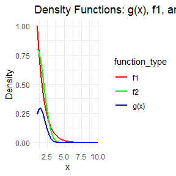

```r
# 加载必要的包
library(ggplot2)

# 定义目标函数 g(x)
g <- function(x) {
  (x^2 / sqrt(2 * pi)) * exp(-x^2 / 2)
}

# 修改后的指数分布作为 f1，定义域在 (1, ∞)
f1_density <- function(x, lambda = 1) {
  ifelse(x >= 1, lambda * exp(-lambda * (x - 1)), 0)
}

# 标准正态分布的 |X|+1 作为 f2，定义域在 (1, ∞)
f2_density <- function(x) {
  ifelse(x >= 1, dnorm(x - 1) + dnorm(-(x - 1)), 0)
}

# 生成绘图范围
x_vals <- seq(1, 10, length.out = 1000)

# 计算密度值
g_vals <- g(x_vals)
f1_vals <- f1_density(x_vals)
f2_vals <- f2_density(x_vals)

# 创建数据框用于绘图
data <- data.frame(
  x = rep(x_vals, 3),
  density = c(g_vals, f1_vals, f2_vals),
  function_type = rep(c("g(x)", "f1", "f2"), each = length(x_vals))
)

# 绘图
ggplot(data, aes(x = x, y = density, color = function_type)) +
  geom_line(size = 1) +
  labs(title = "Density Functions: g(x), f1, and f2",
       x = "x", y = "Density") +
  scale_color_manual(values = c("g(x)" = "blue", "f1" = "red", "f2" = "green")) +
  theme_minimal()
```

可以发现，由修改过的正态分布所得到的密度函数与g函数的密度更接近，选择塔作为重要性函数所产生的方差页更小，这与我们的模拟结论是相符的。

## 第二次第四题

问题描述为：For $n = 10^4, 2 × 10^4, 4 × 10^4, 6 × 10^4, 8 × 10^4$, apply the fast sorting algorithm to randomly permuted numbers of 1, $\ldots$, n. Calculate computation time averaged over 100 simulations, denoted by $a_n$. Regress $a_n$ on $t_n=n*log(n)$, and graphically show the results(scatter plot and regression line).

```r
library(ggplot2)

# 定义快速排序函数
quick_sort <- function(x) {
  if (length(x) <= 1) {
    return(x)
  } else {
    pivot <- x[1]  # 选择第一个元素作为基准
    less <- x[x < pivot]  # 小于基准的元素
    greater <- x[x > pivot]  # 大于基准的元素
    equal <- x[x == pivot]  # 等于基准的元素
    return(c(quick_sort(less), equal, quick_sort(greater)))  # 递归排序
  }
}

# 定义 n 的值
n_values <- c(10^4, 2 * 10^4, 4 * 10^4, 6 * 10^4, 8 * 10^4)

# 设置重复次数
num_simulations <- 100

# 初始化存储平均排序时间的向量
a_n <- numeric(length(n_values))

# 测量排序时间的函数
measure_sort_time <- function(n) {
  times <- numeric(num_simulations)
  for (i in 1:num_simulations) {
    x <- sample(1:n)  # 生成随机排列
    start_time <- Sys.time()
    sorted_x <- quick_sort(x)  # 使用自定义的快速排序
    end_time <- Sys.time()
    times[i] <- as.numeric(difftime(end_time, start_time, units = "secs"))  # 记录时间
  }
  mean(times)  # 返回平均时间
}

# 计算每个 n 的平均排序时间
for (i in seq_along(n_values)) {
  n <- n_values[i]
  a_n[i] <- measure_sort_time(n)
  cat("n =", n, "的平均排序时间:", a_n[i], "秒\n")
}
```

```
## n = 10000 的平均排序时间: 0.02012495 秒
## n = 20000 的平均排序时间: 0.0347965 秒
## n = 40000 的平均排序时间: 0.06872766 秒
## n = 60000 的平均排序时间: 0.1044069 秒
## n = 80000 的平均排序时间: 0.1418665 秒
```

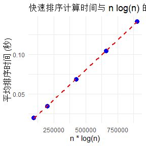

```r
# 计算 tn = n * log(n)
t_n <- n_values * log(n_values)


# 绘制散点图和回归线
data <- data.frame(n_values = n_values, t_n = t_n, a_n = a_n)

ggplot(data, aes(x = t_n, y = a_n)) +
  geom_point(color = "blue", size = 3) +
  geom_smooth(method = "lm", se = FALSE, color = "red", linetype = "dashed") +
  labs(title = "快速排序计算时间与 n log(n) 的关系",
       x = "n * log(n)",
       y = "平均排序时间 (秒)") +
  theme_minimal()
```

# 第三次作业

## 第三次第一题

题目描述为：Estimate the 0.025, 0.05, 0.95, and 0.975 quantiles of the skewness $\sqrt{b_1}$ under normality by a Monte Carlo experiment. Compute the standard error of the estimates from (2.14) using the normal approximation for the density (with exact variance formula). Compare the estimated quantiles with the quantiles of the large sample approximation $\sqrt{b_1}$ ≈ N(0, 6/n).

首先，我们给出在正态性假设下的偏度估计量：

```r
# 设置参数
n <- 10000  # 样本大小
m <- 10000  # Monte Carlo模拟次数
set.seed(1)  # 固定随机种子

# 定义计算偏度的函数
skewness <- function(x) {
  n <- length(x)
  mean_x <- mean(x)
  s3 <- mean((x - mean_x)^3)
  s2 <- mean((x - mean_x)^2)^(3/2)
  return(s3 / s2)
}

# Monte Carlo模拟
skew_values <- numeric(m)  # 存储偏度的结果
for (i in 1:m) {
  sample_data <- rnorm(n)  # 从标准正态分布中生成样本
  skew_values[i] <- skewness(sample_data)
}
```

将估计的分位数和大样本近似的分位数进行比较

```r
quantiles <- quantile(skew_values, c(0.025, 0.05, 0.95, 0.975))
cat("估计的分位数为：\n")
```

```
## 估计的分位数为：
```

```r
print(quantiles)
```

```
##        2.5%          5%         95%       97.5%
## -0.04799941 -0.04002108  0.04090775  0.04817854
```

```r
var_formula <- sqrt(6/n)
cat("理论分位数为：\n")
```

```
## 理论分位数为：
```

```r
theoretical_quantiles <- qnorm(c(0.025, 0.05, 0.95, 0.975), mean = 0, sd = var_formula)
print(theoretical_quantiles)
```

```
## [1] -0.04800912 -0.04029052  0.04029052  0.04800912
```

利用密度的正态近似计算的估计值的标准误差如下所示：

```r
q <- c(0.025, 0.05, 0.95, 0.975)
skew_se_values <- sqrt(q*(1-q)/(n*(dnorm(qnorm(c(0.025, 0.05, 0.95, 0.975), mean = 0, sd = var_formula),mean = 0,sd = var_formula)^2)))
print(skew_se_values)
```

```
## [1] 0.0006543349 0.0005176231 0.0005176231 0.0006543349
```

## 第三次第二题

题目描述如下：Tests for association based on Pearson product moment correlation $\rho$, Spearman’s rank correlation coefficient $\rho_s$, or Kendall’s coefficient $\tau$, are implemented in . Show (empirically) that the nonparametric tests based on $\rho_s$ or $\tau$ are less powerful than the correlation test when the sampled distribution is bivariate normal. Find an example of an alternative (a bivariate distribution $(X, Y)$ such that $X$ and $Y$ are dependent) such that at least one of the nonparametric tests have better empirical power than the correlation test against this alternative.

经过测试，当数据对$(X, \sqrt{|Y|})$满足$(X, Y)$服从均值为0，协方差矩阵为
$$\Sigma = \begin{bmatrix}
1 & 0.01 \\
0.01 & 1
\end{bmatrix}$$
的二元正态分布时，Spearman检验功效和Kendall检验功效均大于Pearson检验功效

```r
# 加载必要的包
library(MASS)  # 用于生成双变量正态分布数据
```

```r
library(ggplot2)

# 设置随机数种子
set.seed(123)

mu <- c(0, 0)  # 均值向量
Sigma <- matrix(c(1, 0.01, 0.01, 1), 2, 2)  # 协方差矩阵
n <- 100  # 样本大小



set.seed(123)
n_sim <- 10000  # 模拟次数
p_vals_pearson <- numeric(n_sim)
p_vals_spearman <- numeric(n_sim)
p_vals_kendall <- numeric(n_sim)

for (i in 1:n_sim) {
  data_sim <- mvrnorm(n, mu, Sigma)
  p_vals_pearson[i] <- cor.test(data_sim[,1], sqrt(abs(data_sim[,2])), method = "pearson")$p.value
  p_vals_spearman[i] <- cor.test(data_sim[,1], sqrt(abs(data_sim[,2])), method = "spearman")$p.value
  p_vals_kendall[i] <- cor.test(data_sim[,1], sqrt(abs(data_sim[,2])), method = "kendall")$p.value
}

# 计算拒绝原假设的比例（即功效）
alpha <- 0.05
power_pearson <- mean(p_vals_pearson < alpha)
power_spearman <- mean(p_vals_spearman < alpha)
power_kendall <- mean(p_vals_kendall < alpha)

cat("\n功效比较：\n")
```

```
##
## 功效比较：
```

```r
cat("Pearson检验功效：", power_pearson, "\n")
```

```
## Pearson检验功效： 0.0507
```

```r
cat("Spearman检验功效：", power_spearman, "\n")
```

```
## Spearman检验功效： 0.0531
```

```r
cat("Kendall检验功效：", power_kendall, "\n")
```

```
## Kendall检验功效： 0.0529
```

## 第三次第三题

问题描述为：If we obtain the powers for two methods under a particular simulation setting with 10,000 experiments: say, 0.651 for one method and 0.676 for another method. We want to know if the powers are different at 0.05 level. What is the corresponding hypothesis test problem? What test should we use? Z-test, two-sample t-test, paired-t test or McNemar test? Why? Please provide the least necessary information for hypothesis testing.

首先我们给出对应的假设检验问题：

$H_0:$ 两种方法所得到的功效相同

$H_1:$ 两种方法所得的的功效不同

然后我们选择Z检验作为我们的检验方式，因为我们对功效的分布没有更多的信息，而t检验主要用于比较较小分布下两个正态分布的样本均值是否有差异，配对t检验用于比较两组配对样本的均值差异，McNemar检验用于分析配对数据的分类变量。而我们拥有较大的样本数量，故选择Z检验比较合理，下面将使用Z检验进行检验。

```r
# 两个方法的统计功效
power1 <- 0.651
power2 <- 0.676

# 实验次数
n <- 10000

# 计算合并后的功效（pooled proportion）
pooled_power <- (power1 + power2) / 2

# 计算两比例差异的标准误
se_diff <- sqrt(pooled_power * (1 - pooled_power) * (2 / n))

# Z检验统计量
z_stat <- (power1 - power2) / se_diff

# 计算双尾检验的p值
p_value <- 2 * (1 - pnorm(abs(z_stat)))

# 输出结果
cat("Z检验统计量:", z_stat, "\n")
```

```
## Z检验统计量: -3.741209
```

```r
cat("p值:", p_value, "\n")
```

```
## p值: 0.0001831369
```

```r
# 在0.05显著性水平下判断是否有显著差异
if (p_value < 0.05) {
  cat("在0.05显著性水平上，两者功效有显著差异。\n")
} else {
  cat("在0.05显著性水平上，两者功效没有显著差异。\n")
}
```

```
## 在0.05显著性水平上，两者功效有显著差异。
```

由上可知，我们在0.05显著水平下否认$H_0$

# 第四次作业

## 第四次第一题

题目描述为：Of N = 1000 hypotheses, 950 are null and 50 are alternative. The p-value under any null hypothesis is uniformly distributed (use runif), and the p-value under any alternative hypothesis follows the beta distribution with parameter 0.1 and 1 (use rbeta). Obtain Bonferroni adjusted p-values and B-H adjusted p-values. Calculate FWER, FDR, and TPR under nominal level α = 0.1 for each of the two adjustment methods based on m = 10000 simulation replicates. You should output the 6 numbers (3 ) to a 3 × 2 table (column names: Bonferroni correction, B-H correction; row names: FWER, FDR, TPR). Comment the results.

下面来计算这些值

```r
set.seed(1)  # 设置随机种子
N <- 1000  # 总假设数量
null_hypotheses <- 950  # 零假设数量
alt_hypotheses <- 50  # 备择假设数量
alpha <- 0.1  # 显著性水平
m <- 10000  # 模拟次数

#初始化
bonferroni_fwer <- numeric(m)
bonferroni_fdr <- numeric(m)
bonferroni_tpr <- numeric(m)
bh_fwer <- numeric(m)
bh_fdr <- numeric(m)
bh_tpr <- numeric(m)


for (i in 1:m) {
  # 生成p值
  p_values <- c(runif(null_hypotheses), rbeta(alt_hypotheses, 0.1, 1))

  # Bonferroni调整
  bonferroni_adjusted <- p.adjust(p_values, method = "bonferroni")

  # Benjamini-Hochberg调整
  bh_adjusted <- p.adjust(p_values, method = "BH")

  #分别计算两种调整下的FWER, FDR, TPR
  bonferroni_fwer[i] <- ifelse(sum(bonferroni_adjusted[1:null_hypotheses] < alpha)>=1,1,0)

  bh_fwer[i] <- ifelse(sum(bh_adjusted[1:null_hypotheses] < alpha)>=1,1,0)

  bonferroni_fdr[i] <- sum(bonferroni_adjusted[1:null_hypotheses] < alpha)/sum(bonferroni_adjusted[1:1000] < alpha)

  bh_fdr[i] <- sum(bh_adjusted[1:null_hypotheses] < alpha)/sum(bonferroni_adjusted[1:1000] < alpha)

  bonferroni_tpr[i] <- sum(bonferroni_adjusted[(null_hypotheses+1):1000] < alpha)/50

  bh_tpr[i] <- sum(bh_adjusted[(null_hypotheses+1):1000] < alpha)/50
}

#构造结果矩阵
results <- matrix(c(mean(bonferroni_fwer),mean(bonferroni_fdr),mean(bonferroni_tpr),mean(bh_fwer),mean(bh_fdr),mean(bh_tpr)),nrow = 3,ncol = 2)
colnames(results) <- c( "Bonferroni correction", "B-H correction")
rownames(results) <- c("FWER", "FDR","TPR")
results
```

```
##      Bonferroni correction B-H correction
## FWER           0.091800000      0.9338000
## FDR            0.004816463      0.1570625
## TPR            0.398074000      0.5629740
```

从表格中可以看出，对于Bonferroni调整更保守，导致了较低的FWER，TPR和FDR，因为它严格控制FWER。B-H方法相对宽松，可能提高TPR和FDR，但FWER控制较弱。

## 第四次第二题

题目描述为：Refer to the air-conditioning data set aircondit provided in the boot package. The 12 observations are the times in hours between failures of airconditioning equipment [63, Example 1.1]: 3, 5, 7, 18, 43, 85, 91, 98, 100, 130, 230, 487. Assume that the times between failures follow an exponential model Exp(λ). Obtain the MLE of the hazard rate λ and use bootstrap to estimate the bias and standard error of the estimate.

我们容易得到对数似然函数为：
$$l(\lambda)
= n\, log(\lambda) - \lambda\sum_{i=1}^{n}{x_i}$$

解得$\lambda$的估计量为$\frac{n}{\sum_{i=1}^n{x_i}}$

```r
# 加载boot包并查看数据
library(boot)
data("aircondit")

# 取出数据
fail_times <- aircondit$hours

# MLE估计
# 在指数分布中，lambda的最大似然估计值是1/均值
lambda_mle <- 1 / mean(fail_times)
cat("MLE of lambda:", lambda_mle, "\n")
```

```
## MLE of lambda: 0.00925212
```

```r
# 定义自助法函数
bootstrap_mle <- function(data, indices) {
  sample_data <- data[indices]
  return(1 / mean(sample_data))  # 重新计算样本的lambda估计值
}

# 使用boot包中的boot函数执行自助法
boot_results <- boot(data = fail_times, statistic = bootstrap_mle, R = 1000)

# 计算偏差和标准误差
lambda_bias <- mean(boot_results$t) - lambda_mle
lambda_se <- sd(boot_results$t)

cat("Bootstrap bias estimate:", lambda_bias, "\n")
```

```
## Bootstrap bias estimate: 0.00132276
```

```r
cat("Bootstrap standard error estimate:", lambda_se, "\n")
```

```
## Bootstrap standard error estimate: 0.004423679
```

由结果知，$\lambda$的估计值为0.00925212，bootstrap的偏差为0.00132276，标准差也比较小。

## 第四次第三题

题目为： Refer to Exercise 7.4. Compute 95% bootstrap confidence intervals for the mean time between failures 1/λ by the standard normal, basic, percentile, and BCa methods. Compare the intervals and explain why they may differ.

```r
# 加载必要的库
library(boot)
data <- c(3, 5, 7, 18, 43, 85, 91, 98, 100, 130, 230, 487)

# 定义一个函数，用于计算平均故障时间 1/λ
mean_time <- function(data, indices) {
  return(mean(data[indices]))  # 返回 1/λ 即平均时间
}

# 使用 bootstrapping 方法进行估计
set.seed(123)  # 确保结果可重复
bootstrap_results <- boot(data, statistic = mean_time, R = 10000)

# 计算不同方法的95%置信区间
ci_normal <- boot.ci(bootstrap_results, type = "norm")
ci_basic <- boot.ci(bootstrap_results, type = "basic")
ci_percentile <- boot.ci(bootstrap_results, type = "perc")
ci_bca <- boot.ci(bootstrap_results, type = "bca")

# 输出结果
cat("对于平均时间的95%置信区间为：\n")
```

```
## 对于平均时间的95%置信区间为：
```

```r
cat("Normal Method CI: ", ci_normal$normal[2], "to", ci_normal$normal[3], "\n")
```

```
## Normal Method CI:  35.05313 to 182.4408
```

```r
cat("Basic Method CI: ", ci_basic$basic[4], "to", ci_basic$basic[5], "\n")
```

```
## Basic Method CI:  25.75417 to 170.0833
```

```r
cat("Percentile Method CI: ", ci_percentile$percent[4], "to", ci_percentile$percent[5], "\n")
```

```
## Percentile Method CI:  46.08333 to 190.4125
```

```r
cat("BCa Method CI: ", ci_bca$bca[4], "to", ci_bca$bca[5], "\n")
```

```
## BCa Method CI:  56.16667 to 221.4406
```

下面简单分析一下不同方法的差异： 标准正态方法基于正态近似，这在样本量大且分布接近正态时较为有效。 基本方法则是基于原始数据的bootstrap样本直接构造置信区间，可能对样本大小敏感。 百分位数方法直接使用bootstrap样本的分位数来构造置信区间，这种方法对极端值敏感。 BCa 方法经过校正的置信区间，结合了偏差和加速因素，通常表现出更好的覆盖率和更少的偏差。

# 第五次作业

##第五次第一题

问题描述为：Refer to Exercise 7.7. Obtain the jackknife estimates of bias and standard error of $\hat{\theta}$.

```r
# 加载所需数据集
library(bootstrap)
scores_data <- scor

# 计算总体的第一个特征值占比
cov_eigenvalues <- eigen(cov(scores_data))$values
initial_theta <- cov_eigenvalues[1] / sum(cov_eigenvalues)

# Jackknife估计
num_samples <- nrow(scores_data)
theta_jackknife <- vector(length = num_samples)

for (sample_index in seq_len(num_samples)) {
  # 排除当前样本并计算协方差矩阵
  reduced_cov <- cov(scores_data[-sample_index, ])
  jackknife_eigenvalues <- eigen(reduced_cov)$values

  # 计算特征值比例
  theta_jackknife[sample_index] <- jackknife_eigenvalues[1] / sum(jackknife_eigenvalues)
}

# 计算Jackknife的偏差和标准误
jackknife_bias <- (num_samples - 1) * (mean(theta_jackknife) - initial_theta)
jackknife_se <- sqrt((num_samples - 1) * mean((theta_jackknife - mean(theta_jackknife))^2))

# 输出结果
cat("Jackknife偏差估计:", jackknife_bias, "\n")
```

```
## Jackknife偏差估计: 0.001069139
```

```r
cat("Jackknife标准误估计:", jackknife_se, "\n")
```

```
## Jackknife标准误估计: 0.04955231
```

## 第五次第二题

问题描述为： In Example 7.18, leave-one-out (n-fold) cross validation was used to select the best fitting model. Repeat the analysis replacing the Log-Log model with a cubic polynomial model. Which of the four models is selected by the cross validation procedure? Which model is selected according to maximum adjusted $X^2$?

三次多项式模型为：
$$Y=\beta_0+\beta_1X+\beta_2X^2+\beta_3X^3+\epsilon$$

```r
# 加载数据
library(DAAG)
attach(ironslag)
num_samples <- length(magnetic)

# 初始化误差向量
errors_model1 <- errors_model2 <- errors_model3 <- errors_model4 <- numeric(num_samples)

# n 折交叉验证
for (i in 1:num_samples) {
  response <- magnetic[-i]
  predictor <- chemical[-i]

  # 模型1: 线性模型
  model1 <- lm(response ~ predictor)
  pred1 <- model1$coef[1] + model1$coef[2] * chemical[i]
  errors_model1[i] <- magnetic[i] - pred1

  # 模型2: 二次回归模型
  model2 <- lm(response ~ predictor + I(predictor^2))
  pred2 <- model2$coef[1] + model2$coef[2] * chemical[i] + model2$coef[3] * chemical[i]^2
  errors_model2[i] <- magnetic[i] - pred2

  # 模型3: 指数模型
  model3 <- lm(log(response) ~ predictor)
  log_pred3 <- model3$coef[1] + model3$coef[2] * chemical[i]
  pred3 <- exp(log_pred3)
  errors_model3[i] <- magnetic[i] - pred3

  # 模型4: 三次回归模型
  model4 <- lm(response ~ predictor + I(predictor^2) + I(predictor^3))
  pred4 <- model4$coef[1] + model4$coef[2] * chemical[i] + model4$coef[3] * chemical[i]^2 + model4$coef[4] * chemical[i]^3
  errors_model4[i] <- magnetic[i] - pred4
}

# 计算每个模型的平均平方误差
mse_results <- c(mean(errors_model1^2), mean(errors_model2^2), mean(errors_model3^2), mean(errors_model4^2))
cat("各模型的均方误差为:", mse_results, "\n")
```

```
## 各模型的均方误差为: 19.55644 17.85248 18.44188 18.17756
```

```r
# 比较调整后的 R^2
response_var <- magnetic
predictor_var <- chemical

adj_r2_values <- c(
  summary(lm(response_var ~ predictor_var))$adj.r.squared,
  summary(lm(response_var ~ predictor_var + I(predictor_var^2)))$adj.r.squared,
  summary(lm(log(response_var) ~ predictor_var))$adj.r.squared,
  summary(lm(response_var ~ predictor_var + I(predictor_var^2) + I(predictor_var^3)))$adj.r.squared
)
cat("各模型的调整后 R^2 值为:", adj_r2_values, "\n")
```

```
## 各模型的调整后 R^2 值为: 0.5281545 0.5768151 0.5280556 0.5740396
```

我们可以说误差平方和最小的还是二号模型，值为17.85248，而根据调整后的$R^2$值，二号模型的值最大，所以二号模型拟合的最好。

## 第五次第三题

问题描述为： Implement the two-sample Cram´er-von Mises test for equal distributions as a permutation test. Apply the test to the data in Examples 8.1 and 8.2.

```r
# 加载数据
attach(chickwts)
group1 <- sort(weight[feed == "soybean"])
group2 <- sort(weight[feed == "linseed"])
detach(chickwts)

# 定义 Cramér-von Mises 检验的统计量函数
compute_cvm <- function(group1, group2) {
  n1 <- length(group1)
  n2 <- length(group2)
  combined_samples <- sort(c(group1, group2))
  ecdf1 <- ecdf(group1)(combined_samples)
  ecdf2 <- ecdf(group2)(combined_samples)

  # 计算统计量
  statistic <- (n1 * n2 / (n1 + n2)^2) * sum((ecdf1 - ecdf2)^2)
  return(statistic)
}

# 计算原始数据的统计量
observed_stat <- compute_cvm(group1, group2)

# 置换检验的设置
set.seed(123)  # 保证结果可重复
num_permutations <- 1000
perm_stats <- numeric(num_permutations)

for (j in 1:num_permutations) {
  shuffled_data <- sample(c(group1, group2))
  perm_group1 <- shuffled_data[1:length(group1)]
  perm_group2 <- shuffled_data[(length(group1) + 1):length(shuffled_data)]
  perm_stats[j] <- compute_cvm(perm_group1, perm_group2)
}

# 计算 p 值
p_value <- mean(c(observed_stat, perm_stats) >= observed_stat)
cat("Cramér-von Mises 置换检验的 p 值:", p_value, "\n")
```

```
## Cramér-von Mises 置换检验的 p 值: 0.4225774
```

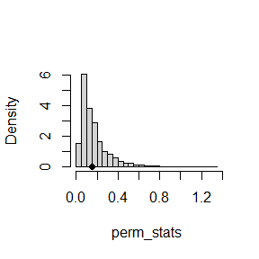

```r
# 绘制置换分布的直方图
hist(perm_stats, main = "", freq = FALSE, breaks = "scott")
points(observed_stat, 0, cex = 1, pch = 16)  # 标出观测到的统计量
```

得到的p值是0.4225774，不拒绝原假设，喂不同饲料的鸡的体重分布可能没有区别。

## 第五次第四题

问题描述为：Implement the bivariate Spearman rank correlation test for independence [255] as a permutation test. The Spearman rank correlation test statistic can be obtained from function cor with method = “spearman”. Compare the achieved significance level of the permutation test with the p-value reported by cor.test on the same samples.

```r
set.seed(1)
x <- rnorm(50)
y <- rnorm(50)

# 使用 cor 函数计算 Spearman 秩相关系数
observed_stat <- cor(x, y, method = "spearman")

# 设置置换检验参数
num_permutations <- 1000
perm_stats <- numeric(num_permutations)

# 置换检验
for (i in 1:num_permutations) {
  perm_y <- sample(y)
  perm_stats[i] <- cor(x, perm_y, method = "spearman")
}

# 计算置换检验的 p 值
p_value_perm <- mean(abs(perm_stats) >= abs(observed_stat))
cat("置换检验的 p 值:", p_value_perm, "\n")
```

```
## 置换检验的 p 值: 0.337
```

```r
# 使用 cor.test 函数计算 Spearman 检验的 p 值
test_result <- cor.test(x, y, method = "spearman")
cat("cor.test 的 p 值:", test_result$p.value, "\n")
```

```
## cor.test 的 p 值: 0.3482088
```

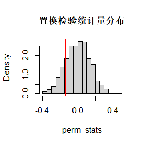

```r
# 绘制置换检验统计量的直方图
hist(perm_stats, main = "置换检验统计量分布", freq = FALSE, breaks = "scott")
abline(v = observed_stat, col = "red", lwd = 2)
```

# 第六次作业

## 第六次第一题

问题描述为：Use the Metropolis-Hastings sampler to generate random variables from a standard Cauchy distribution. Discard the first 1000 of the chain, and compare the deciles of the generated observations with the deciles of the standard Cauchy distribution (see qcauchy or qt with $\mathrm{df}=1$ ). Recall that a $\operatorname{Cauchy}(\theta, \eta)$ distribution has density function
$$f(x)=\frac{1}{\theta \pi\left(1+[(x-\eta) / \theta]^2\right)},
\quad-\infty<x<\infty, \theta>0 .$$

The standard Cauchy has the $\operatorname{Cauchy}(\theta=1, \eta=0)$ density. (Note that the standard Cauchy density is equal to the Student $t$ density with one degree of freedom.)

```r
# 设置参数
set.seed(123)
n <- 10000  # 生成样本数
burn_in <- 1000 # 丢弃的前1000个样本
x <- numeric(n)  # 存储生成的样本
x[1] <- 0  # 初始值

# Metropolis-Hastings 采样
for (i in 2:n) {
  # 使用正态分布作为提议分布
  proposal <- x[i - 1] + rnorm(1, mean = 0, sd = 1)

  # 计算接受率
  alpha <- dcauchy(proposal, location = 0, scale = 1) / dcauchy(x[i - 1], location = 0, scale = 1)

  # 接受或拒绝
  if (runif(1) < alpha) {
    x[i] <- proposal
  } else {
    x[i] <- x[i - 1]
  }
}

# 丢弃前1000个样本
samples <- x[(burn_in + 1):n]

# 计算生成样本的分位数
sample_deciles <- quantile(samples, probs = seq(0.1, 0.9, by = 0.1))

# 计算标准柯西分布的分位数
true_deciles <- qcauchy(seq(0.1, 0.9, by = 0.1))

# 对比结果
result <- data.frame(Sample_Deciles = sample_deciles, True_Deciles = true_deciles)

print(result)
```

```
##     Sample_Deciles True_Deciles
## 10%    -2.81748908   -3.0776835
## 20%    -1.40266892   -1.3763819
## 30%    -0.73784530   -0.7265425
## 40%    -0.33350883   -0.3249197
## 50%    -0.01642563    0.0000000
## 60%     0.30706020    0.3249197
## 70%     0.72330174    0.7265425
## 80%     1.37266697    1.3763819
## 90%     3.02836810    3.0776835
```

可以看出，结果还不错

## 第六次第二题

问题描述为：This example appears in [40]. Consider the bivariate density
$$f(x, y) \propto\binom{n}{x} y^{x+a-1}(1-y)^{n-x+b-1}, \quad x=0,1,
\ldots, n, 0 \leq y \leq 1$$

It can be shown (see e.g. [23]) that for fixed $a, b, n$, the conditional distributions are $\operatorname{Binomial}(n, y)$ and $\operatorname{Beta}(x+a, n-x+b)$. Use the Gibbs sampler to generate a chain with target joint density $f(x, y)$.

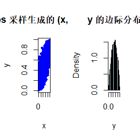

```r
# 设置参数
set.seed(123)
n <- 10      # 二项分布的样本数量
a <- 2       # Beta 分布的参数 a
b <- 2       # Beta 分布的参数 b
iterations <- 10000  # Gibbs 采样的总迭代次数

# 初始化向量
x <- numeric(iterations)
y <- numeric(iterations)
y[1] <- 0.5  # 给定初始值

# Gibbs 采样过程
for (i in 2:iterations) {
  # 给定 y[i - 1] 采样
  x[i] <- rbinom(1, n, y[i - 1])

  # 给定 x[i] 采样
  y[i] <- rbeta(1, x[i] + a, n - x[i] + b)
}

burn <- 1000
x_samples <- x[(burn + 1):iterations]
y_samples <- y[(burn + 1):iterations]

# 绘图：展示采样结果
par(mfrow = c(1, 2))
plot(x_samples, y_samples, pch = 20, col = "blue",
     main = "Gibbs 采样生成的 (x, y) 样本点", xlab = "x", ylab = "y")
hist(y_samples, probability = TRUE, col = "lightblue",
     main = "y 的边际分布", xlab = "y")
```

## 第六次第三题

问题描述为：For each of the above exercise, use the Gelman-Rubin method to monitor convergence of the chain, and run the chain until it converges approximately to the target distribution according to $\hat{R}<1.2$.

第一题代码的Gelman-Rubin统计量，运行三条链

```r
# 设置参数
set.seed(123)
chains <- 3
n <- 10000
burn_in <- 1000
samples_list <- list()

for (j in 1:chains) {
  x <- numeric(n)
  x[1] <- 0

  for (i in 2:n) {
    proposal <- x[i - 1] + rnorm(1, mean = 0, sd = 1)
    alpha <- dcauchy(proposal, location = 0, scale = 1) / dcauchy(x[i - 1], location = 0, scale = 1)
    if (runif(1) < alpha) {
      x[i] <- proposal
    } else {
      x[i] <- x[i - 1]
    }
  }

  samples_list[[j]] <- x[(burn_in + 1):n]
}

# Gelman-Rubin 手动计算
m <- chains
n_samples <- n - burn_in
chain_means <- sapply(samples_list, mean)
overall_mean <- mean(chain_means)
chain_vars <- sapply(samples_list, var)

# 计算链内方差 W
W <- mean(chain_vars)

# 计算链间方差 B
B <- n_samples * var(chain_means)

# 计算总方差估计 V
V <- ((n_samples - 1) / n_samples) * W + (1 / n_samples) * B

# 计算 Gelman-Rubin 统计量
R_hat <- sqrt(V / W)

cat("Gelman-Rubin 统计量 (R_hat) 为:", R_hat, "\n")
```

```
## Gelman-Rubin 统计量 (R_hat) 为: 1.014286
```

第二题的Gelman-Rubin统计量，运行三条链

```r
# 设置参数
set.seed(123)
n <- 10
a <- 2
b <- 2
chains <- 3
iterations <- 10000
burn_in <- 1000
y_initial <- 0.5
samples_list_x <- list()
samples_list_y <- list()

for (j in 1:chains) {
  x <- numeric(iterations)
  y <- numeric(iterations)
  y[1] <- y_initial

  for (i in 2:iterations) {
    x[i] <- rbinom(1, n, y[i - 1])
    y[i] <- rbeta(1, x[i] + a, n - x[i] + b)
  }

  samples_list_x[[j]] <- x[(burn_in + 1):iterations]
  samples_list_y[[j]] <- y[(burn_in + 1):iterations]
}

# Gelman-Rubin 手动计算 X 的 R_hat
chain_means_x <- sapply(samples_list_x, mean)
overall_mean_x <- mean(chain_means_x)
chain_vars_x <- sapply(samples_list_x, var)
W_x <- mean(chain_vars_x)
B_x <- n_samples * var(chain_means_x)
V_x <- ((n_samples - 1) / n_samples) * W_x + (1 / n_samples) * B_x
R_hat_x <- sqrt(V_x / W_x)

cat("Gelman-Rubin 统计量 X (R_hat) 为:", R_hat_x, "\n")
```

```
## Gelman-Rubin 统计量 X (R_hat) 为: 0.9999908
```

```r
# Gelman-Rubin 手动计算 Y 的 R_hat
chain_means_y <- sapply(samples_list_y, mean)
overall_mean_y <- mean(chain_means_y)
chain_vars_y <- sapply(samples_list_y, var)
W_y <- mean(chain_vars_y)
B_y <- n_samples * var(chain_means_y)
V_y <- ((n_samples - 1) / n_samples) * W_y + (1 / n_samples) * B_y
R_hat_y <- sqrt(V_y / W_y)

cat("Gelman-Rubin 统计量 Y (R_hat) 为:", R_hat_y, "\n")
```

```
## Gelman-Rubin 统计量 Y (R_hat) 为: 0.9999714
```

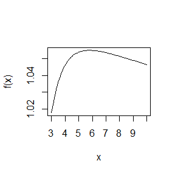

```r
f <- function(x) log(x+log(x))/log(1+x)
curve(f,3,10)
```

```r
res <- optimize(f,lower=4,upper=8,maximum=FALSE)
res
```

```
## $minimum
## [1] 7.99994
##
## $objective
## [1] 1.051553
```

# 第七次作业

## 第七次第一题

问题描述为：(a) Write a function to compute the $k^{t h}$ term in
$$\sum_{k=0}^{\infty} \frac{(-1)^k}{k!2^k} \frac{\|a\|^{2 k+2}}{(2 k+1)(2
k+2)} \frac{\Gamma\left(\frac{d+1}{2}\right)
\Gamma\left(k+\frac{3}{2}\right)}{\Gamma\left(k+\frac{d}{2}+1\right)}$$
where $d \geq 1$ is an integer, $a$ is a vector in $\mathbb{R}^d$, and $\|\cdot\|$ denotes the Euclidean norm. Perform the arithmetic so that the coefficients can be computed for (almost) arbitrarily large $k$ and $d$. (This sum converges for all $a \in \mathbb{R}^d$ ). (b) Modify the function so that it computes and returns the sum. (c) Evaluate the sum when $a=(1,2)^T$.

(a)我们首先构造计算第k项的函数，使得对于几乎任意的k和d都能计算

```r
compute_kth_term <- function(k, a) {
  # 计算 Euclidean 范数
  norm_a <- sqrt(sum(a^2))
  d <- length(a)

  if (is.double(k)==TRUE){
  #为了防止k过大导致gamma函数值和幂值过大，先取log
  log_gamma_part <-lgamma((d+1)/2)+lgamma(k+3/2)-lgamma(k+d/2+1)-lgamma(k+1)
  log_norm_part <- k*log(norm_a^2/2)
  # 返回第 k 项
  return((-1)^k *(norm_a^2)* exp(log_norm_part+log_gamma_part-log(2*k+1)-log(2*k+2)))}
  else {return("error")}
}
compute_kth_term(1000,c(1,2))
```

```
## [1] 0
```

(b)下面构造求和函数

```r
compute_sum <- function(a, tol = 1e-20, max_iter = 1000) {
  sum_value <- 0
  d <- length(a)
  k <- 0

  repeat {
    term <- compute_kth_term(k, a)
    sum_value <- sum_value + term

    # 检查是否满足收敛条件
    if (abs(term) < tol || k >= max_iter) break

    k <- k + 1
  }

  return(sum_value)
}
```

(3)最后计算$a=(1,2)^T$时的值

```r
compute_sum(c(1,2))
```

```
## [1] 1.532164
```

## 第七次第二题

问题描述为：Write a function to solve the equation
$$\begin{aligned}
& \frac{2 \Gamma\left(\frac{k}{2}\right)}{\sqrt{\pi(k-1)
\Gamma\left(\frac{k-1}{2}\right)}}
\int_0^{c_{k-1}}\left(1+\frac{u^2}{k-1}\right)^{-k / 2} d u \\
& \quad=\frac{2 \Gamma\left(\frac{k+1}{2}\right)}{\sqrt{\pi k}
\Gamma\left(\frac{k}{2}\right)}
\int_0^{c_k}\left(1+\frac{u^2}{k}\right)^{-(k+1) / 2} d u
\end{aligned}$$
for $a$, where
$$c_k=\sqrt{\frac{a^2 k}{k+1-a^2}} .$$

Compare the solutions with the points $A(k)$ in Exercise 11.4.

我们构造如下的函数用来计算使等式成立的a

```r
# 定义 c_k 函数
c_k <- function(a, k) {
  sqrt(a^2 * k / (k + 1 - a^2))
}

# 定义方程左边的积分和表达式
lhs <- function(a, k) {
  ck_minus_1 <- c_k(a, k - 1)
  integrand_lhs <- function(u) (1 + u^2 / (k - 1))^(-k / 2)

  integral_lhs <- integrate(integrand_lhs, 0, ck_minus_1)$value

  2 * exp(lgamma(k / 2)-lgamma((k - 1) / 2)) / sqrt(pi * (k - 1))  * integral_lhs
}

# 定义方程右边的积分和表达式
rhs <- function(a, k) {
  ck <- c_k(a, k)
  integrand_rhs <- function(u) (1 + u^2 / k)^(-(k + 1) / 2)

  integral_rhs <- integrate(integrand_rhs, 0, ck)$value
  2 * exp(lgamma((k+1) / 2)-lgamma(k/ 2)) / sqrt(pi * k) * integral_rhs
}

# 定义方程的差值（左右两边差）
equation <- function(a, k=100) {
  lhs(a, k) - rhs(a, k)
}

# 给定 k 值求解 a
solve_for_a <- function(k, interval = c(0.1,min(3,sqrt(k)-1e-5))) {
  uniroot(equation, interval = interval, k = k)$root
}

# 示例：在不同的 k 值下求解 a 并输出结果
k_values <- c(4:25,100,500,1000)  # 可以根据需要更改 k 的范围
solutions <- sapply(k_values, solve_for_a)

# 打印结果
for (i in seq_along(k_values)) {
  cat("当 k =", k_values[i], "时，a 的解为:", solutions[i], "\n")
}
```

```
## 当 k = 4 时，a 的解为: 1.492105
## 当 k = 5 时，a 的解为: 1.533559
## 当 k = 6 时，a 的解为: 1.562746
## 当 k = 7 时，a 的解为: 1.584429
## 当 k = 8 时，a 的解为: 1.601168
## 当 k = 9 时，a 的解为: 1.614497
## 当 k = 10 时，a 的解为: 1.625362
## 当 k = 11 时，a 的解为: 1.634409
## 当 k = 12 时，a 的解为: 1.642026
## 当 k = 13 时，a 的解为: 1.648538
## 当 k = 14 时，a 的解为: 1.65417
## 当 k = 15 时，a 的解为: 1.659109
## 当 k = 16 时，a 的解为: 1.663443
## 当 k = 17 时，a 的解为: 1.667291
## 当 k = 18 时，a 的解为: 1.67073
## 当 k = 19 时，a 的解为: 1.673822
## 当 k = 20 时，a 的解为: 1.676601
## 当 k = 21 时，a 的解为: 1.679125
## 当 k = 22 时，a 的解为: 1.681493
## 当 k = 23 时，a 的解为: 1.68361
## 当 k = 24 时，a 的解为: 1.685558
## 当 k = 25 时，a 的解为: 1.687356
## 当 k = 100 时，a 的解为: 1.720599
## 当 k = 500 时，a 的解为: 1.729728
## 当 k = 1000 时，a 的解为: 1.730877
```

下面是11.4中的A(k)

```r
# 定义 S_{k-1}(a) 函数
S_k_minus_1 <- function(a, k) {
  threshold <- sqrt(a^2 * (k - 1) / (k - a^2))
  1 - pt(threshold, df = k - 1)
}

# 定义 S_k(a) 函数
S_k <- function(a, k) {
  threshold <- sqrt(a^2 * k / (k + 1 - a^2))
  1 - pt(threshold, df = k)
}

# 定义交点方程的差值
equation <- function(a, k) {
  S_k_minus_1(a, k) - S_k(a, k)
}

# 求解 a 使得 S_{k-1}(a) = S_k(a)
solve_for_Ak <- function(k, interval = c(0.01, min(3,sqrt(k)-1e-5))) {
  uniroot(equation, interval = interval, k = k)$root
}

# 在不同的 k 值下找到交点 A(k)
k_values <- c(4:25, 100, 500, 1000)
solutions <- sapply(k_values, solve_for_Ak)

# 输出结果
for (i in seq_along(k_values)) {
  cat("当 k =", k_values[i], "时，交点 A(k) 的解为:", solutions[i], "\n")
}
```

```
## 当 k = 4 时，交点 A(k) 的解为: 1.492103
## 当 k = 5 时，交点 A(k) 的解为: 1.533559
## 当 k = 6 时，交点 A(k) 的解为: 1.562741
## 当 k = 7 时，交点 A(k) 的解为: 1.584431
## 当 k = 8 时，交点 A(k) 的解为: 1.601157
## 当 k = 9 时，交点 A(k) 的解为: 1.614538
## 当 k = 10 时，交点 A(k) 的解为: 1.625358
## 当 k = 11 时，交点 A(k) 的解为: 1.634409
## 当 k = 12 时，交点 A(k) 的解为: 1.642026
## 当 k = 13 时，交点 A(k) 的解为: 1.64851
## 当 k = 14 时，交点 A(k) 的解为: 1.654182
## 当 k = 15 时，交点 A(k) 的解为: 1.659098
## 当 k = 16 时，交点 A(k) 的解为: 1.663408
## 当 k = 17 时，交点 A(k) 的解为: 1.667286
## 当 k = 18 时，交点 A(k) 的解为: 1.670754
## 当 k = 19 时，交点 A(k) 的解为: 1.673823
## 当 k = 20 时，交点 A(k) 的解为: 1.676618
## 当 k = 21 时，交点 A(k) 的解为: 1.679157
## 当 k = 22 时，交点 A(k) 的解为: 1.681473
## 当 k = 23 时，交点 A(k) 的解为: 1.683596
## 当 k = 24 时，交点 A(k) 的解为: 1.685547
## 当 k = 25 时，交点 A(k) 的解为: 1.687348
## 当 k = 100 时，交点 A(k) 的解为: 1.720626
## 当 k = 500 时，交点 A(k) 的解为: 1.729745
## 当 k = 1000 时，交点 A(k) 的解为: 1.730897
```

可以发现，11.5中使等式成立的解和11.4中的解相同

## 第七次第三题

问题描述为：Suppose $T_1, \ldots, T_n$ are i.i.d. samples drawn from the exponential distribution with expectation $\lambda$. Those values greater than $\tau$ are not observed due to right censorship, so that the observed values are $Y_i=T_i l\left(T_i \leq \tau\right)+\tau l\left(T_i>\tau\right)$, $i=1, \ldots, n$. Suppose $\tau=1$ and the observed $Y_i$ values are as follows:
$$0.54,0.48,0.33,0.43,1.00,1.00,0.91,1.00,0.21,0.85$$

Use the E-M algorithm to estimate $\lambda$, compare your result with the observed data MLE (note: $Y_i$ follows a mixture distribution).

```r
# 初始化数据
observed_data <- c(0.54, 0.48, 0.33, 0.43, 1.00, 1.00, 0.91, 1.00, 0.21, 0.85)
tau <- 1  # 截尾点
n <- length(observed_data)

# E-M 算法
estimate_lambda_em <- function(data, tau, tol = 1e-6, max_iter = 1000) {
  # 初始化 lambda
  lambda <- 1 / mean(data)  # 初始值

  for (i in 1:max_iter) {
    # E 步骤: 计算每个被截尾值的期望
    truncated_data <- data[data == tau]  # 被截尾的值
    untruncated_data <- data[data < tau]  # 未截尾的值

    # 对于截尾的观测值，计算其条件期望
    expected_truncated <- sum(truncated_data + 1 / lambda)

    # M 步骤: 更新 lambda
    lambda_new <- n / (sum(untruncated_data) + expected_truncated)

    # 检查收敛
    if (abs(lambda - lambda_new) < tol) break
    lambda <- lambda_new
  }

  return(lambda)
}

# 计算 EM 算法的 lambda
lambda_em <- estimate_lambda_em(observed_data, tau)

# 使用观测数据直接计算 MLE
observed_untruncated <- observed_data[observed_data < tau]
lambda_mle <- 1 / mean(observed_untruncated)

# 输出结果
cat("EM 算法估计的 λ:", lambda_em, "\n")
```

```
## EM 算法估计的 λ: 1.037038
```

```r
cat("使用观测数据直接计算的 MLE λ:", lambda_mle, "\n")
```

```
## 使用观测数据直接计算的 MLE λ: 1.866667
```

# 第八次作业

## 第八次第一题

问题描述为：Use the simplex algorithm to solve the following problem. Minimize $4 x+2 y+9 z$ subject to
$$\begin{aligned}
& 2 x+y+z \leq 2 \\
& x-y+3 z \leq 3 \\
& x \geq 0, y \geq 0, z \geq 0
\end{aligned}$$

```r
library(boot) #for simplex function
A1 <- rbind(c(2, 1, 1), c(1, -1, 3))
b1 <- c(2, 3)
a <- c(4, 2, 9)
simplex(a = a, A1 = A1, b1 = b1, maxi = FALSE)
```

```
##
## Linear Programming Results
##
## Call : simplex(a = a, A1 = A1, b1 = b1, maxi = FALSE)
##
## Minimization Problem with Objective Function Coefficients
## x1 x2 x3
##  4  2  9
##
##
## Optimal solution has the following values
## x1 x2 x3
##  0  0  0
## The optimal value of the objective  function is 0.
```

最小值为0，当取值为(0,0,0)时取到

## 第八次第二题

题目描述为：Use both for loops and lapply() to fit linear models to the mtcars using the formulas stored in this list:

```
formulas <- list(
    mpg ~ disp,
    mpg ~ I(1 / disp),
    mpg ~ disp + wt,
    mpg ~ I(1 / disp) + wt
)
```

使用for循环的情况如下：

```r
# 定义公式列表
formulas <- list(
  mpg ~ disp,
  mpg ~ I(1 / disp),
  mpg ~ disp + wt,
  mpg ~ I(1 / disp) + wt
)

# 初始化一个空列表存储模型
models_for_1 <- list()

# 使用for循环拟合模型
for (i in seq_along(formulas)) {
  models_for_1[[i]] <- lm(formulas[[i]], data = mtcars)
}

# 查看结果
models_for_1
```

```
## [[1]]
##
## Call:
## lm(formula = formulas[[i]], data = mtcars)
##
## Coefficients:
## (Intercept)         disp
##    29.59985     -0.04122
##
##
## [[2]]
##
## Call:
## lm(formula = formulas[[i]], data = mtcars)
##
## Coefficients:
## (Intercept)    I(1/disp)
##       10.75      1557.67
##
##
## [[3]]
##
## Call:
## lm(formula = formulas[[i]], data = mtcars)
##
## Coefficients:
## (Intercept)         disp           wt
##    34.96055     -0.01772     -3.35083
##
##
## [[4]]
##
## Call:
## lm(formula = formulas[[i]], data = mtcars)
##
## Coefficients:
## (Intercept)    I(1/disp)           wt
##      19.024     1142.560       -1.798
```

使用lapply函数的情况如下：

```r
# 使用lapply()拟合模型
models_lapply_1 <- lapply(formulas, function(f) lm(f, data = mtcars))

# 查看结果
models_lapply_1
```

```
## [[1]]
##
## Call:
## lm(formula = f, data = mtcars)
##
## Coefficients:
## (Intercept)         disp
##    29.59985     -0.04122
##
##
## [[2]]
##
## Call:
## lm(formula = f, data = mtcars)
##
## Coefficients:
## (Intercept)    I(1/disp)
##       10.75      1557.67
##
##
## [[3]]
##
## Call:
## lm(formula = f, data = mtcars)
##
## Coefficients:
## (Intercept)         disp           wt
##    34.96055     -0.01772     -3.35083
##
##
## [[4]]
##
## Call:
## lm(formula = f, data = mtcars)
##
## Coefficients:
## (Intercept)    I(1/disp)           wt
##      19.024     1142.560       -1.798
```

可以看出，使用两种方式算出的结果是相同的

## 第八次第三题

题目描述为：Fit the model mpg ~ disp to each of the bootstrap replicates of mtcars in the list below by using a for loop and lapply(). Can you do it without an anonymous function?

```
bootstraps <- lapply(1:10, function(i) {
    rows <- sample(1:nrow(mtcars), rep = TRUE)
    mtcars[rows, ]
})
```

使用for循环的情况如下：

```r
set.seed(1)
# 创建bootstrap样本列表
bootstraps <- list()
for (i in 1:10) {
  rows <- sample(1:nrow(mtcars), replace = TRUE)
  bootstraps[[i]] <- mtcars[rows, ]
}

models_for_2 <- list()

# 对每个bootstrap样本拟合模型
for (i in seq_along(bootstraps)) {
  models_for_2[[i]] <- lm(mpg ~ disp, data = bootstraps[[i]])
}

# 查看结果
models_for_2
```

```
## [[1]]
##
## Call:
## lm(formula = mpg ~ disp, data = bootstraps[[i]])
##
## Coefficients:
## (Intercept)         disp
##     26.4707      -0.0296
##
##
## [[2]]
##
## Call:
## lm(formula = mpg ~ disp, data = bootstraps[[i]])
##
## Coefficients:
## (Intercept)         disp
##    30.58356     -0.04291
##
##
## [[3]]
##
## Call:
## lm(formula = mpg ~ disp, data = bootstraps[[i]])
##
## Coefficients:
## (Intercept)         disp
##    30.30606     -0.04375
##
##
## [[4]]
##
## Call:
## lm(formula = mpg ~ disp, data = bootstraps[[i]])
##
## Coefficients:
## (Intercept)         disp
##    30.34619     -0.04572
##
##
```

[output cut: 43 more lines]

```
## lm(formula = mpg ~ disp, data = bootstraps[[i]])
##
## Coefficients:
## (Intercept)         disp
##    27.28341     -0.03452
##
##
## [[10]]
##
## Call:
## lm(formula = mpg ~ disp, data = bootstraps[[i]])
##
## Coefficients:
## (Intercept)         disp
##    27.53057     -0.03053
```

使用lapply函数的情况如下：

```r
set.seed(1)
# 定义一个函数生成bootstrap样本
generate_bootstrap <- function(index) {
  rows <- sample(1:nrow(mtcars), replace = TRUE)
  mtcars[rows, ]
}

# 使用lapply()生成bootstrap样本
bootstraps <- lapply(1:10, generate_bootstrap)

# 定义一个函数拟合模型
fit_model <- function(data) {
  lm(mpg ~ disp, data = data)
}

# 使用lapply()对每个bootstrap样本拟合模型
models_lapply_2 <- lapply(bootstraps, fit_model)

# 查看结果
models_lapply_2
```

```
## [[1]]
##
## Call:
## lm(formula = mpg ~ disp, data = data)
##
## Coefficients:
## (Intercept)         disp
##     26.4707      -0.0296
##
##
## [[2]]
##
## Call:
## lm(formula = mpg ~ disp, data = data)
##
## Coefficients:
## (Intercept)         disp
##    30.58356     -0.04291
##
##
## [[3]]
##
## Call:
## lm(formula = mpg ~ disp, data = data)
##
## Coefficients:
## (Intercept)         disp
##    30.30606     -0.04375
##
##
## [[4]]
##
## Call:
## lm(formula = mpg ~ disp, data = data)
##
## Coefficients:
## (Intercept)         disp
##    30.34619     -0.04572
##
##
```

[output cut: 43 more lines]

```
## lm(formula = mpg ~ disp, data = data)
##
## Coefficients:
## (Intercept)         disp
##    27.28341     -0.03452
##
##
## [[10]]
##
## Call:
## lm(formula = mpg ~ disp, data = data)
##
## Coefficients:
## (Intercept)         disp
##    27.53057     -0.03053
```

## 第八次第四题

题目描述为：For each model in the previous two exercises, extract $R^2$ using the function below. rsq <- function(mod) summary(mod)$r.squared

第二题中模型的$R^2$为：

```r
r_lapply_1 <- lapply(models_lapply_1, function(mod) summary(mod)$r.squared)

unlist(r_lapply_1)
```

```
## [1] 0.7183433 0.8596865 0.7809306 0.8838038
```

第三题中的模型的$R^2$为：

```r
r_lapply_2 <- lapply(models_lapply_2, function(mod) summary(mod)$r.squared)

unlist(r_lapply_2)
```

```
##  [1] 0.5491998 0.6804651 0.6946612 0.7952022 0.8062361 0.8057083 0.8061748
##  [8] 0.6943378 0.6041705 0.6102182
```

## 第八次第五题

问题描述为： The following code simulates the performance of a t-test for non-normal data. Use sapply() and an anonymous function to extract the p-value from every trial.

```
trials <- replicate(
    100,
    t.test(rpois(10, 10), rpois(7, 10)),
    simplify = FALSE
)
```

Extra challenge: get rid of the anonymous function by using [[ directly.

使用sapply函数：

```r
set.seed(1)
# 模拟100次t检验
trials <- replicate(
  100,
  t.test(rpois(10, 10), rpois(7, 10)),
  simplify = FALSE
)

# 使用sapply()和匿名函数提取p值
p_values <- sapply(trials, function(x) x$p.value)

# 查看部分结果
head(p_values)
```

```
## [1] 0.1259499 0.8009303 0.9528553 0.4529599 0.4830835 0.3206111
```

避免使用匿名函数：

```r
set.seed(1)
# 使用sapply()直接提取p值
p_values_direct <- sapply(trials, `[[`, "p.value")

# 查看部分结果
head(p_values_direct)
```

```
## [1] 0.1259499 0.8009303 0.9528553 0.4529599 0.4830835 0.3206111
```

## 第八次第六题

题目描述为：Implement a combination of Map() and vapply() to create an lapply() variant that iterates in parallel over all of its inputs and stores its outputs in a vector (or a matrix). What arguments should the function take?

我们构造的符合函数是：

```r
Map_vapply <- function(FUN, ..., FUN.VALUE) {
  # 使用 Map() 对所有输入进行并行迭代
  results <- Map(FUN, ...)

  # 使用 vapply() 将结果强制转换为向量或矩阵
  vapply(results, identity, FUN.VALUE)
}
```

我们对上一题使用这个函数，计算每次t检验的p值

```r
set.seed(1)
list1 <- replicate(100,rpois(10, 10),simplify = FALSE)
list2 <- replicate(100,rpois(7, 10),simplify = FALSE)
head(Map_vapply(FUN = function(x,y) t.test(x,y)$p.value,list1,list2,FUN.VALUE = numeric(1)))
```

```
## [1] 0.56244291 0.33841773 0.83636176 0.38279981 0.06709744 0.68706097
```

## 第八次第七题

问题描述为：Make a faster version of chisq.test() that only computes the chi-square test statistic when the input is two numeric vectors with no missing values. You can try simplifying chisq.test() or by coding from the mathematical definition

```r
fast_chisq_test <- function(x, y) {
  # 生成列联表（contingency table）
  tbl <- table(x, y)

  # 计算行总计和列总计
  row_sums <- rowSums(tbl)
  col_sums <- colSums(tbl)
  total <- sum(tbl)

  # 计算期望频数
  expected <- outer(row_sums, col_sums, "*") / total

  # 计算卡方统计量
  chisq_stat <- sum((tbl - expected)^2 / expected)

  return(chisq_stat)
}
x <- c(1,1,1,2,2,2,2,2,1,1)
y <- c(1,1,1,2,1,1,2,2,2,2)

# 使用快速卡方检验
fast_chisq_test(x, y)
```

```
## [1] 0.4
```

## 第八次第八题

问题描述为：Can you make a faster version of table() for the case of an input of two integer vectors with no missing values? Can you use it to speed up your chi-square test?

快速table函数：

```r
fast_table <- function(x, y) {
  # 确定值的范围
  x_levels <- sort(unique(x))
  y_levels <- sort(unique(y))

  # 创建零初始化的频数矩阵
  tbl <- matrix(0, nrow = length(x_levels), ncol = length(y_levels),
                dimnames = list(x_levels, y_levels))

  # 填充频数矩阵
  for (i in seq_along(x)) {
    tbl[x[i], y[i]] <- tbl[x[i], y[i]] + 1
  }

  return(tbl)
}
```

使用快速table的快速卡方检验：

```r
fast_chisq_test1 <- function(x, y) {
  # 使用快速 table() 构造列联表
  tbl <- fast_table(x, y)

  # 计算行和、列和以及总和
  row_sums <- rowSums(tbl)
  col_sums <- colSums(tbl)
  total <- sum(tbl)

  # 计算期望频数矩阵
  expected <- outer(row_sums, col_sums, "*") / total

  # 计算卡方统计量
  chisq_stat <- sum((tbl - expected)^2 / expected)

  return(chisq_stat)
}
```

```r
set.seed(123)
x <- sample(1:5, 1e5, replace = TRUE)
y <- sample(1:5, 1e5, replace = TRUE)
tbl <- table(x, y)
chisq_stat <- chisq.test(x, y)$statistic
chisq_stat_fast <- fast_chisq_test(x, y)
chisq_stat - chisq_stat_fast
```

```
## X-squared
##         0
```

# 第九次作业

## 第九次第一题

问题描述为：This example appears in [40]. Consider the bivariate density
$$f(x, y) \propto\binom{n}{x} y^{x+a-1}(1-y)^{n-x+b-1}, \quad x=0,1,
\ldots, n, 0 \leq y \leq 1$$

It can be shown (see e.g. [23]) that for fixed $a, b, n$, the conditional distributions are $\operatorname{Binomial}(n, y)$ and $\operatorname{Beta}(x+a, n-x+b)$. Use the Gibbs sampler to generate a chain with target joint density $f(x, y)$.Write an Rcpp function for Exercise 9.8 (page 278, Statistical Computing with R).Compare the corresponding generated random numbers with those by the R function you wrote using the function “qqplot”Campare the computation time of the two functions with the function “microbenchmark”.

以下是Rcpp的实现代码：

```cpp
#include <Rcpp.h>
using namespace Rcpp;

// [[Rcpp::export]]
NumericMatrix gibbs_rcpp(int n_samples, int n, double a, double b, int x_init, double y_init) {
  NumericMatrix samples(n_samples, 2);
  int x = x_init;
  double y = y_init;

  for (int i = 0; i < n_samples; ++i) {
    // Update x ~ Binomial(n, y)
    x = R::rbinom(n, y);

    // Update y ~ Beta(x+a, n-x+b)
    y = R::rbeta(x + a, n - x + b);

    // Store the samples
    samples(i, 0) = x;
    samples(i, 1) = y;
  }

  return samples;
}
```

以下是R的实现代码：

```r
gibbs_r <- function(n_samples, n, a, b, x_init, y_init) {
  samples <- matrix(0, nrow = n_samples, ncol = 2)
  x <- x_init
  y <- y_init

  for (i in 1:n_samples) {
    # Update x ~ Binomial(n, y)
    x <- rbinom(1, n, y)

    # Update y ~ Beta(x+a, n-x+b)
    y <- rbeta(1, x + a, n - x + b)

    # Store the samples
    samples[i, ] <- c(x, y)
  }

  return(samples)
}
```

使用 qqplot 比较Rcpp和R生成的随机数是否一致：

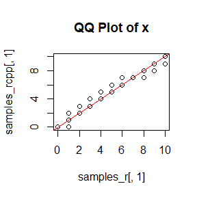

```r
# 参数设置
n_samples <- 1000
n <- 10
a <- 2
b <- 3
x_init <- 5
y_init <- 0.5

# 调用Rcpp和R函数
samples_rcpp <- gibbs_rcpp(n_samples, n, a, b, x_init, y_init)
samples_r <- gibbs_r(n_samples, n, a, b, x_init, y_init)

# QQ图比较x的分布
qqplot(samples_r[, 1], samples_rcpp[, 1], main = "QQ Plot of x")
abline(0, 1, col = "red")
```

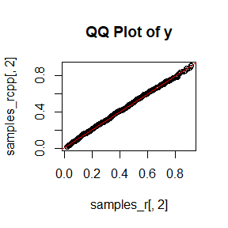

```r
# QQ图比较y的分布
qqplot(samples_r[, 2], samples_rcpp[, 2], main = "QQ Plot of y")
abline(0, 1, col = "red")
```

结果显示两种方式生成的分布基本一样。

接下来比较两种方法的运算速度：

```r
library(microbenchmark)
benchmark_results <- microbenchmark(
  Rcpp = gibbs_rcpp(n_samples, n, a, b, x_init, y_init),
  R = gibbs_r(n_samples, n, a, b, x_init, y_init),
  times = 100
)

print(benchmark_results)
```

```
## Unit: microseconds
##  expr    min      lq     mean  median      uq    max neval cld
##  Rcpp  208.7  217.65  248.344  225.45  236.45 1730.1   100  a
##     R 2346.0 2449.00 2720.068 2558.75 2729.20 4980.8   100   b
```

结果显示，使用Rcpp的运算结果显著比使用R的结果好，平均时间缩短了90%。